# Final Project Report

Riya Mishra

December 13, 2020

```r
library(DataComputing)
library(mosaic)
library(readr)
library(tidyr)
```

### Guiding Question

Is there a particular region in the world that’s happier than other regions?

What lead me to this research question is how all the countries are dealing with covid. Some countries are doing great and currently have little to no cases. However, some countries are seeing a surge of new cases like never before. This got me thinking, is there a correlation between how happy a country is overall and how they are dealing with the pandemic? I initially wanted my second dataset to be a “covid cases by country” data set. However, there were no data sets I was able to find since they keep updating them every hour and wouldn’t match my other data set. Also, given the time we had for the project, I wouldn’t be able to wrangle all the data on time for the final report. Hence, I decided to check which countries were the happiest in general and maybe check if there was a correlation to the covid cases on my own.

### Data Access

My primary data set is “The World Happiness” data set. The World Happiness is collected through a landmark survey from the Gallup World Poll. The report continues to gain global recognition as governments, organizations and civil society increasingly use happiness indicators to inform their policy-making decisions. The data started getting collected in 2012. The survey is collected by individuals who live in the country. They’re asked to rate each question on a scale of 1 - 10. Once the data is collected, the Gallup World Poll creates an average value for each variable. It started to get collected as the United Nation started coming together and found that these surveys can help them laws and decision that will benefit their countries and to create awareness to authoritites about how their citizens feel. For this project, I will be using the 2015 data set.

My second data set is “The Crime/Safety Index by Country”. It is collected and maintained by the company, Numbeo. The Crime/Safety Index by Country first started getting collected in 2012 as well. The reason they started collecting this data is determine what countries are deemed more dangerous and which are deemed more safe and to find out what can be done to improve or maintain the scores. Since I wanted the data from this dataset to be compatible with the World Happiness, I used the 2015 Crime/Safety Index data.

To attach my first dataset, I converted my .csv file to a .txt file and uploaded it onto the Stat184FinalProject notebook. Then, I clicked on Import Dataset in Environment and renamed the dataset from “2015” to “WorldHappiness”. To make sure that the dataset was uploaded and saved, I ran the code “View(WorldHappiness)” and I successfully was able to view the dataset table. Next, I tried to extract certain variables to ensure that I can access and manipulate the dataset.

```r
WorldHappiness%>%
  select(Country, Region, Happiness.Rank)
```

| Country | Region | Happiness.Rank |
| --- | --- | --- |
| Switzerland | Western Europe | 1 |
| Iceland | Western Europe | 2 |
| Denmark | Western Europe | 3 |
| Norway | Western Europe | 4 |
| Canada | North America | 5 |
| Finland | Western Europe | 6 |
| Netherlands | Western Europe | 7 |
| Sweden | Western Europe | 8 |
| New Zealand | Australia and New Zealand | 9 |
| Australia | Australia and New Zealand | 10 |

[output cut: 148 more lines]

For my next dataset, I used the HTML tables format since the dataset was embedded onto the site. I was successfully able to create a table after loading the dataset using read_html().

```r
library(rvest)
web_page <- "https://www.numbeo.com/crime/rankings_by_country.jsp?title=2015"
SetOfTables <- web_page %>%
  read_html() %>%
  html_nodes(css = "table") %>%
  html_table(fill = TRUE)
length(SetOfTables)
```

```
[1] 2
```

```r
CrimeandSafety <- SetOfTables[[2]]
CrimeandSafety
```

| Rank | Country | Crime Index | Safety Index |
| --- | --- | --- | --- |
| NA | South Sudan | 85.32 | 14.68 |
| NA | Venezuela | 84.07 | 15.93 |
| NA | Guatemala | 79.34 | 20.66 |
| NA | South Africa | 78.44 | 21.56 |
| NA | Afghanistan | 77.34 | 22.66 |
| NA | Guyana | 76.88 | 23.12 |
| NA | Nigeria | 76.60 | 23.40 |
| NA | Trinidad And Tobago | 75.28 | 24.72 |
| NA | Honduras | 74.91 | 25.09 |
| NA | Bahamas | 72.93 | 27.07 |

[output cut: 137 more lines]

I tested to see if I can extract tables from the dataset.

```r
CrimeandSafety%>%
  select(Country, `Crime Index`, `Safety Index`)
```

| Country | Crime Index | Safety Index |
| --- | --- | --- |
| South Sudan | 85.32 | 14.68 |
| Venezuela | 84.07 | 15.93 |
| Guatemala | 79.34 | 20.66 |
| South Africa | 78.44 | 21.56 |
| Afghanistan | 77.34 | 22.66 |
| Guyana | 76.88 | 23.12 |
| Nigeria | 76.60 | 23.40 |
| Trinidad And Tobago | 75.28 | 24.72 |
| Honduras | 74.91 | 25.09 |
| Bahamas | 72.93 | 27.07 |

[output cut: 137 more lines]

### Insepcting the Data

Now, I am going to inspect my data sets using a few summary R functions.

```r
head(CrimeandSafety) # grabbing the first few rows of Crime/Safety Index
```

|  | Rank | Country | Crime Index | Safety Index |
| --- | --- | --- | --- | --- |
| 1 | NA | South Sudan | 85.32 | 14.68 |
| 2 | NA | Venezuela | 84.07 | 15.93 |
| 3 | NA | Guatemala | 79.34 | 20.66 |
| 4 | NA | South Africa | 78.44 | 21.56 |
| 5 | NA | Afghanistan | 77.34 | 22.66 |
| 6 | NA | Guyana | 76.88 | 23.12 |

```r
nrow(CrimeandSafety) # counting the number of cases in the data frame
```

```
[1] 147
```

```r
nrow(WorldHappiness) # counting the number of cases in the data frame for World Happiness
```

```
[1] 158
```

```r
names(WorldHappiness) # checking the variable names in World Happiness data frame
```

```
 [1] "Country"                       "Region"                        "Happiness.Rank"
 [4] "Happiness.Score"               "Standard.Error"                "Economy..GDP.per.Capita."
 [7] "Family"                        "Health..Life.Expectancy."      "Freedom"
[10] "Trust..Government.Corruption." "Generosity"                    "Dystopia.Residual"
```

```r
names(CrimeandSafety) # checking the variable names in Crime/Safety Index
```

```
[1] "Rank"         "Country"      "Crime Index"  "Safety Index"
```

### Data Wrangling

First, I’m going to merge the two datasets together so I can wrangle the data with both datasets as a whole.

```r
MergedTable <-
  CrimeandSafety%>%
  left_join(WorldHappiness, by = c("Country"))
```

```
Column `Country` joining character vector and factor, coercing into character vector
```

```r
MergedTable
```

| Rank | Country | Crime Index | Safety Index | Region | Happiness.Rank | Happiness.Score | Standard.Error | Economy..GDP.per.Capita. | Family | Health..Life.Expectancy. | Freedom | Trust..Government.Corruption. | Generosity | Dystopia.Residual |
| --- | --- | --- | --- | --- | --- | --- | --- | --- | --- | --- | --- | --- | --- | --- |
| NA | South Sudan | 85.32 | 14.68 | NA | NA | NA | NA | NA | NA | NA | NA | NA | NA | NA |
| NA | Venezuela | 84.07 | 15.93 | Latin America and Caribbean | 23 | 6.810 | 0.06476 | 1.04424 | 1.25596 | 0.72052 | 0.42908 | 0.11069 | 0.05841 | 3.19131 |
| NA | Guatemala | 79.34 | 20.66 | Latin America and Caribbean | 43 | 6.123 | 0.05224 | 0.74553 | 1.04356 | 0.64425 | 0.57733 | 0.09472 | 0.27489 | 2.74255 |
| NA | South Africa | 78.44 | 21.56 | Sub-Saharan Africa | 113 | 4.642 | 0.04585 | 0.92049 | 1.18468 | 0.27688 | 0.33207 | 0.08884 | 0.11973 | 1.71956 |
| NA | Afghanistan | 77.34 | 22.66 | Southern Asia | 153 | 3.575 | 0.03084 | 0.31982 | 0.30285 | 0.30335 | 0.23414 | 0.09719 | 0.36510 | 1.95210 |
| NA | Guyana | 76.88 | 23.12 | NA | NA | NA | NA | NA | NA | NA | NA | NA | NA | NA |
| NA | Nigeria | 76.60 | 23.40 | Sub-Saharan Africa | 78 | 5.268 | 0.04192 | 0.65435 | 0.90432 | 0.16007 | 0.34334 | 0.04030 | 0.27233 | 2.89319 |
| NA | Trinidad And Tobago | 75.28 | 24.72 | NA | NA | NA | NA | NA | NA | NA | NA | NA | NA | NA |
| NA | Honduras | 74.91 | 25.09 | Latin America and Caribbean | 105 | 4.788 | 0.05648 | 0.59532 | 0.95348 | 0.69510 | 0.40148 | 0.06825 | 0.23027 | 1.84408 |
| NA | Bahamas | 72.93 | 27.07 | NA | NA | NA | NA | NA | NA | NA | NA | NA | NA | NA |

[output cut: 137 more lines]

I’m not a big fan of the Column names for some of the variables. So, I will change them to my liking so it’s easier to interpret and type as I’m working through the project. Also, I want to select certain tables for my reserach instead of the whole thing. So I will create a data frame with everything I want to use for my research.

```r
CleanedTable<-
  MergedTable%>%
  rename(Safety = `Safety Index`, Crime = `Crime Index`, HappinessRank = Happiness.Rank, StandardError =
           Standard.Error, HLE = Health..Life.Expectancy., HappinessScore = Happiness.Score, GovTrust =
           Trust..Government.Corruption., Dystopia = Dystopia.Residual)%>%
  select(Country, Crime, Safety, Region, HappinessScore,HappinessRank, HLE, Freedom, GovTrust, Generosity,Dystopia )
CleanedTable
```

| Country | Crime | Safety | Region | HappinessScore | HappinessRank | HLE | Freedom | GovTrust | Generosity | Dystopia |
| --- | --- | --- | --- | --- | --- | --- | --- | --- | --- | --- |
| South Sudan | 85.32 | 14.68 | NA | NA | NA | NA | NA | NA | NA | NA |
| Venezuela | 84.07 | 15.93 | Latin America and Caribbean | 6.810 | 23 | 0.72052 | 0.42908 | 0.11069 | 0.05841 | 3.19131 |
| Guatemala | 79.34 | 20.66 | Latin America and Caribbean | 6.123 | 43 | 0.64425 | 0.57733 | 0.09472 | 0.27489 | 2.74255 |
| South Africa | 78.44 | 21.56 | Sub-Saharan Africa | 4.642 | 113 | 0.27688 | 0.33207 | 0.08884 | 0.11973 | 1.71956 |
| Afghanistan | 77.34 | 22.66 | Southern Asia | 3.575 | 153 | 0.30335 | 0.23414 | 0.09719 | 0.36510 | 1.95210 |
| Guyana | 76.88 | 23.12 | NA | NA | NA | NA | NA | NA | NA | NA |
| Nigeria | 76.60 | 23.40 | Sub-Saharan Africa | 5.268 | 78 | 0.16007 | 0.34334 | 0.04030 | 0.27233 | 2.89319 |
| Trinidad And Tobago | 75.28 | 24.72 | NA | NA | NA | NA | NA | NA | NA | NA |
| Honduras | 74.91 | 25.09 | Latin America and Caribbean | 4.788 | 105 | 0.69510 | 0.40148 | 0.06825 | 0.23027 | 1.84408 |
| Bahamas | 72.93 | 27.07 | NA | NA | NA | NA | NA | NA | NA | NA |

[output cut: 137 more lines]

I recognized that a lot of countries around the same area have similar names. For example, countries in the Middle East usually end with a “tan”" in the end. Hence, I want to check if Countries that ended in a similar way had a lower or higher score and if the different conuntry names do relate to each other. This will help me understand the different areas of the World and if countries with similar names and around each other have a similar happiness score.

```r
SpecificCountry <-
  CleanedTable %>%
  filter(grepl("tan", Country, ignore.case = TRUE)) %>%
  arrange(desc(HappinessScore))
SpecificCountry
```

| Country | Crime | Safety | Region | HappinessScore | HappinessRank | HLE | Freedom | GovTrust | Generosity | Dystopia |
| --- | --- | --- | --- | --- | --- | --- | --- | --- | --- | --- |
| Uzbekistan | 58.13 | 41.87 | Central and Eastern Europe | 6.003 | 44 | 0.59772 | 0.65821 | 0.30826 | 0.22837 | 2.23741 |
| Kazakhstan | 46.68 | 53.32 | Central and Eastern Europe | 5.855 | 54 | 0.64368 | 0.51649 | 0.08454 | 0.11827 | 2.24729 |
| Turkmenistan | 17.86 | 82.14 | Central and Eastern Europe | 5.548 | 70 | 0.53886 | 0.47610 | 0.30844 | 0.16979 | 1.86984 |
| Kyrgyzstan | 65.07 | 34.93 | Central and Eastern Europe | 5.286 | 77 | 0.65088 | 0.43477 | 0.04232 | 0.30030 | 2.23270 |
| Pakistan | 61.16 | 38.84 | Southern Asia | 5.194 | 81 | 0.51466 | 0.12102 | 0.10464 | 0.33671 | 3.10709 |
| Tanzania | 61.80 | 38.20 | Sub-Saharan Africa | 3.781 | 146 | 0.38215 | 0.32878 | 0.05747 | 0.34377 | 1.38079 |
| Afghanistan | 77.34 | 22.66 | Southern Asia | 3.575 | 153 | 0.30335 | 0.23414 | 0.09719 | 0.36510 | 1.95210 |

Looking at this table, I don’t really see a correlation with country name and similarities in variables. Hence, I can conclude that countries that have similar names do not have similar scores throughout all the variables.

Next, I’m curious to know the average happiness score within all regions. This will give me an idea of what region has the highest score. I will be able to determine why by focusing on the highest and lowest score.

```r
GatherTable <-
  CleanedTable %>%
  filter(! is.na(Region))%>%
  group_by(Region) %>%
  summarise(avg = mean(HappinessScore)) %>%
  gather(key = Region, value = avg)%>%
  arrange(desc(avg))
GatherTable
```

| Region | avg |
| --- | --- |
| Australia and New Zealand | 7.285000 |
| North America | 7.273000 |
| Western Europe | 6.739350 |
| Latin America and Caribbean | 6.137300 |
| Eastern Asia | 5.626167 |
| Middle East and Northern Africa | 5.443316 |
| Central and Eastern Europe | 5.372960 |
| Southeastern Asia | 5.317444 |
| Sub-Saharan Africa | 4.500312 |
| Southern Asia | 4.468833 |

Here, we can see that Australia and New Zealand Region has the highest average Happiness Score of 7.285. On the other hand, the region with the lowest average score is the Southern Asia region with a score of 4.469.

I want to get the average score for each variable in each region. This will make analyzing the data per region a lot better since we’re looking at regions as a whole rather than individual Countries.

```r
AverageScores<-
  CleanedTable %>%
  filter(! is.na(Region))%>%
  group_by(Region)%>%
  summarise(AvgHappScore = mean(HappinessScore) , AvgCrime = mean(Crime),AvgGovTrust = mean(GovTrust), AvgDystopia = mean(Dystopia), AvgHLE = mean(HLE), AvgFreedom = mean(Freedom),  AvgSafety = mean(Safety), AvgGenerosity = mean(Generosity))%>%
  arrange(desc(AvgHappScore))
AverageScores
```

| Region | AvgHappScore | AvgCrime | AvgGovTrust | AvgDystopia | AvgHLE | AvgFreedom | AvgSafety | AvgGenerosity |
| --- | --- | --- | --- | --- | --- | --- | --- | --- |
| Australia and New Zealand | 7.285000 | 40.96000 | 0.39279500 | 2.265355 | 0.9199650 | 0.6453100 | 59.04000 | 0.4553150 |
| North America | 7.273000 | 43.73500 | 0.24423500 | 2.480935 | 0.8837100 | 0.5895050 | 56.26500 | 0.4295800 |
| Western Europe | 6.739350 | 35.66800 | 0.23589600 | 2.178800 | 0.9084275 | 0.5529090 | 64.33200 | 0.3041295 |
| Latin America and Caribbean | 6.137300 | 61.61450 | 0.12150250 | 2.631847 | 0.7131060 | 0.4941430 | 38.38550 | 0.2151490 |
| Eastern Asia | 5.626167 | 31.89167 | 0.12769500 | 1.681607 | 0.8773883 | 0.4624900 | 68.10833 | 0.2258850 |
| Middle East and Northern Africa | 5.443316 | 45.40737 | 0.18447316 | 1.976649 | 0.7080084 | 0.3678963 | 54.59263 | 0.1944737 |
| Central and Eastern Europe | 5.372960 | 38.29640 | 0.09039480 | 1.997512 | 0.7245228 | 0.3697248 | 61.70360 | 0.1372456 |
| Southeastern Asia | 5.317444 | 44.14556 | 0.15127556 | 1.783020 | 0.6773567 | 0.5571044 | 55.85444 | 0.4192611 |
| Sub-Saharan Africa | 4.500312 | 55.04187 | 0.11879625 | 2.005914 | 0.3184225 | 0.3858838 | 44.95813 | 0.2320669 |
| Southern Asia | 4.468833 | 58.07333 | 0.09388333 | 2.079907 | 0.5352900 | 0.3468833 | 41.92667 | 0.3183367 |

Australia and New Zealand region have the highest average happiness score. Hence, I want to see if they have the best scores for every other variable. They have one of the lowest crime index, one of the highest safety index, highest government trust index, the highest generosity, highest health life expectancy (HLE), and the highest freedom index. I would say in general, the Australia and New Zealand have the best ratings compared to the other regions.

### Data Visualization

Since we want to see which region is happiest, I decided to make a few graphs for visualization.

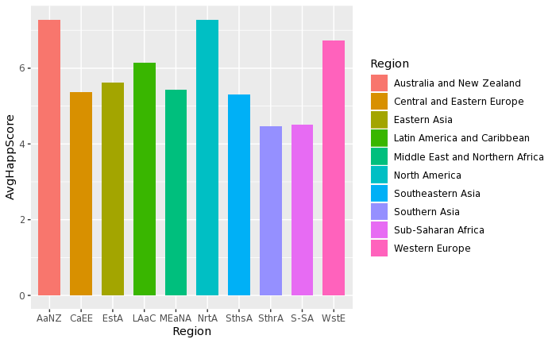

```r
AverageScores%>%
  ggplot(aes(x= Region,y= AvgHappScore,fill= Region))+geom_bar(stat='identity', width=0.7) + scale_x_discrete(labels = abbreviate)
```

I wanted to make a general barplot that helps me depict the different regions and their average happiness scores. As mentioned before, Australia and New Zealand has the highest happiness score. North America comes to a close second. And according to this graph, Western Europe region would come at third place.

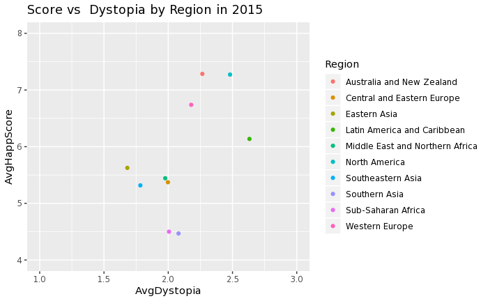

```r
AverageScores%>%
  ggplot(aes(x = AvgDystopia, y =  AvgHappScore )) + geom_point( ) + aes(colour= Region)+ ggtitle("Score vs  Dystopia by Region in 2015") + ylim(4, 8) + xlim(1,3)
```

Next, I decided to use the Average Dystopia vs the Average Happiness Score. The Average Dystopia is the lowest scores observed for the 6 key variables. A higher the dystopia, the more unhappy people can be in a given Country. So, looking at this plot, I can see that Australia and New Zealand have the highest happiness score and an average dystopia score. North America has a high happiness score but a higher Dystopia score. So, this means that there are very unhappy people in North America and dystopia really hurts their average happiness socre. Western Europe, which is number three based off of average happiness score, has a lower dystopia score compared to the top two regions. This drasitcally helps the Western Europe region since there aren’t too many unhappy people there. I would say Australia and New Zealand region is happier than other regions and Western Europe region would come second.

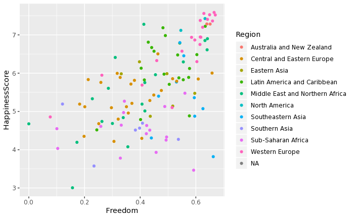

```r
CleanedTable %>%
   ggplot(aes(x = Freedom, y =  HappinessScore)) + geom_point() + aes(colour= Region)
```

I wanted to make a Freedom vs Happiness because many individuals value freedom and I think it plays a big part of happiness. Looking at this plot, it’s evident that the Western Europe region and Australia and New Zealand region have the most freedom and the higher scores of happiness.

### Conclusion

Tying this back to how I originially came up with this research, I was curious to see if there was a correlation between the happiness score of countries and how well they were handling the pandemic. Australia, as of December 13, only has 6 new cases and 908 total deaths. I would say that Australia is dealing really well with the pandemic and there could be some correlation between how happy the people in the country are and how they control the pandemic.